# mpl_toolkits.mplot3d.axes3d.Axes3D.stem

**Axes3D.stem(*x*, *y*, *z*, *, *linefmt='C0-'*, *markerfmt='C0o'*, *basefmt='C3-'*, *bottom=0*, *label=None*, *orientation='z'*, *data=None*)[[source]](https://github.com/matplotlib/matplotlib/blob/v3.9.2/lib/mpl_toolkits/mplot3d/axes3d.py#L3617-L3732)**

Create a 3D stem plot.

A stem plot draws lines perpendicular to a baseline, and places markers at the heads. By default, the baseline is defined by *x* and *y*, and stems are drawn vertically from *bottom* to *z*.

**Parameters:**

**x, y, z**array-like**

The positions of the heads of the stems. The stems are drawn along the *orientation*-direction from the baseline at *bottom* (in the *orientation*-coordinate) to the heads. By default, the *x* and *y* positions are used for the baseline and *z* for the head position, but this can be changed by *orientation*.

**linefmt**str, default: 'C0-'**

A string defining the properties of the vertical lines. Usually, this will be a color or a color and a linestyle:

| Character | Line Style |
| --- | --- |
| `'-'` | solid line |
| `'--'` | dashed line |
| `'-.'` | dash-dot line |
| `':'` | dotted line |

Note: While it is technically possible to specify valid formats other than color or color and linestyle (e.g. 'rx' or '-.'), this is beyond the intention of the method and will most likely not result in a reasonable plot.

**markerfmt**str, default: 'C0o'**

A string defining the properties of the markers at the stem heads.

**basefmt**str, default: 'C3-'**

A format string defining the properties of the baseline.

**bottom**float, default: 0**

The position of the baseline, in *orientation*-coordinates.

**label**str, optional**

The label to use for the stems in legends.

**orientation**{'x', 'y', 'z'}, default: 'z'**

The direction along which stems are drawn.

**data**indexable object, optional**

If given, all parameters also accept a string `s`, which is interpreted as `data[s]` (unless this raises an exception).

**Returns:**

**`StemContainer`**

The container may be treated like a tuple (*markerline*, *stemlines*, *baseline*)

#### Examples

([`Source code`](https://matplotlib.org/stable/_downloads/1fbb58d502ed9a7088a2ade19d7ca1c6/stem3d_demo.py), [`2x.png`](https://matplotlib.org/stable/_downloads/637be93b7e35f366da0dee31146666a9/stem3d_demo_00_00.2x.png), [`png`](https://matplotlib.org/stable/_downloads/5834e9146e5baeb85a4dfb152d32dac4/stem3d_demo_00_00.png))

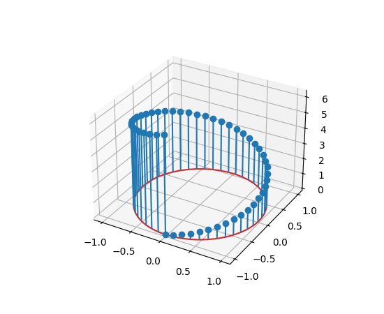

([`2x.png`](https://matplotlib.org/stable/_downloads/e770d4d7793563a0145db1144561f216/stem3d_demo_01_00.2x.png), [`png`](https://matplotlib.org/stable/_downloads/e16fd027b183d3cec3d1cac953925761/stem3d_demo_01_00.png))

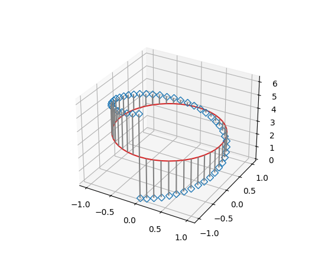

([`2x.png`](https://matplotlib.org/stable/_downloads/6c3417f2564c72a4e9426cdfd2837f71/stem3d_demo_02_00.2x.png), [`png`](https://matplotlib.org/stable/_downloads/aa75822728ded904624b8810c33fb310/stem3d_demo_02_00.png))

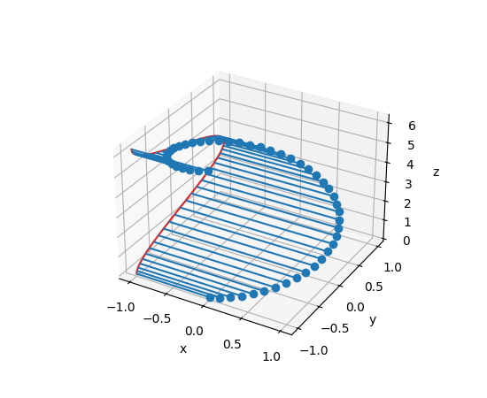

## Examples using `mpl_toolkits.mplot3d.axes3d.Axes3D.stem`

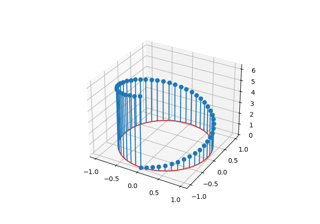

[3D stem](https://matplotlib.org/stable/gallery/mplot3d/stem3d_demo.html#sphx-glr-gallery-mplot3d-stem3d-demo-py)

3D stem

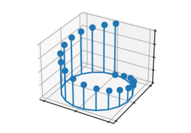

[stem(x, y, z)](https://matplotlib.org/stable/plot_types/3D/stem3d.html#sphx-glr-plot-types-3d-stem3d-py)

stem(x, y, z)

© 2012–2023 Matplotlib Development Team. All rights reserved.  
Licensed under the Matplotlib License Agreement.  
https://matplotlib.org/stable/api/_as_gen/mpl_toolkits.mplot3d.axes3d.Axes3D.stem.html